# IMPORTING necessary library to clean & visualization the data set provided

```python
import numpy as np
import pandas as pd
```

```python
import matplotlib.pyplot as plt
import seaborn as sns
```

```python
# to read the data present in the .csv file format
data  = pd.read_csv('youtube_dislike_dataset.csv')
```

```python
# help in getting the range of row present in the given data
data.index
```

```
RangeIndex(start=0, stop=37422, step=1)
```

```python
# help in getting all the columns present in the given data
data.columns
```

```
Index(['video_id', 'title', 'channel_id', 'channel_title', 'published_at',
       'view_count', 'likes', 'dislikes', 'comment_count', 'tags',
       'description', 'comments'],
      dtype='object')
```

# QUESTION NO 1.

# Import required libraries and read the provided dataset (youtube_dislike_dataset.csv) and retrieve top 5 and bottom 5 records.

```python
# help in getting the first 5 rows of the given data
data.head()
```

|  | video_id | title | channel_id | channel_title | published_at | view_count | likes | dislikes | comment_count | tags | description | comments |
| --- | --- | --- | --- | --- | --- | --- | --- | --- | --- | --- | --- | --- |
| 0 | --0bCF-iK2E | Jadon Sancho Magical Skills & Goals | UC6UL29enLNe4mqwTfAyeNuw | Bundesliga | 2021-07-01 10:00:00 | 1048888 | 19515 | 226 | 1319 | football soccer ftbol alemn Bundesliga season ... | Enjoy the best skills and goals from Jadon San... | Respect to Dortmund fans,must be sad losing hi... |
| 1 | --14w5SOEUs | Migos - Avalanche (Official Video) | UCGIelM2Dj3zza3xyV3pL3WQ | MigosVEVO | 2021-06-10 16:00:00 | 15352638 | 359277 | 7479 | 18729 | Migos Avalanche Quality Control Music/Motown R... | Watch the the official video for Migos - "Aval... | Migos just makes me want to live my live to th... |
| 2 | --40TEbZ9Is | Supporting Actress in a Comedy: 73rd Emmys | UClBKH8yZRcM4AsRjDVEdjMg | Television Academy | 2021-09-20 01:03:32 | 925281 | 11212 | 401 | 831 |  | Hannah Waddingham wins the Emmy for Supporting... | Hannah's energy bursts through any screen. Wel... |
| 3 | --4tfbSyYDE | JO1'YOUNG (JO1 ver.)' PERFORMANCE VIDEO | UCsmXiDP8S40uBeJYxvyulmA | JO1 | 2021-03-03 10:00:17 | 2641597 | 39131 | 441 | 3745 | PRODUCE101JAPAN JO1 TheSTAR STA... | JO1'YOUNG (JO1 ver.)' PERFORMANCE VIDEO\n\n---... | youngVer>< REN is really PERFECT. It's not ju... |
| 4 | --DKkzWVh-E | Why Retaining Walls Collapse | UCMOqf8ab-42UUQIdVoKwjlQ | Practical Engineering | 2021-12-07 13:00:00 | 715724 | 32887 | 367 | 1067 | retaining wall New Jersey highway Direct Conne... | One of the most important (and innocuous) part... | Keep up with all my projects here: https://pr... |

```python
# help in getting the last 5 rows of the given data
data.tail()
```

|  | video_id | title | channel_id | channel_title | published_at | view_count | likes | dislikes | comment_count | tags | description | comments |
| --- | --- | --- | --- | --- | --- | --- | --- | --- | --- | --- | --- | --- |
| 37417 | zzd4ydafGR0 | Lil Tjay - Calling My Phone (feat. 6LACK) [Off... | UCEB4a5o_6KfjxHwNMnmj54Q | Lil Tjay | 2021-02-12 05:03:49 | 120408275 | 2180780 | 35871 | 81360 | Lil Tjay Steady Calling My Phone Calling My Ph... | Official video for "Calling My Phone" by Lil T... | 'DESTINED 2 WIN' OUT NOW !! https://liltjay.ln... |
| 37418 | zziBybeSAtw | PELICANS at LAKERS \| FULL GAME HIGHLIGHTS \| Ja... | UCWJ2lWNubArHWmf3FIHbfcQ | NBA | 2021-01-16 05:39:05 | 2841917 | 20759 | 1049 | 2624 | NBA G League Basketball game-0022000187 Lakers... | PELICANS at LAKERS \| FULL GAME HIGHLIGHTS \| Ja... | Montrezl Harrell is going crazy with the rebou... |
| 37419 | zzk09ESX7e0 | [MV] (MAMAMOO) - Where Are We Now | UCuhAUMLzJxlP1W7mEk0_6lA | MAMAMOO | 2021-06-02 09:00:10 | 13346678 | 720854 | 4426 | 90616 | MAMAMOO WAW WAW MAMAMOO WAW Where Are We Now... | [MV] (MAMAMOO) - Where Are We Now\n\nInstagra... | I honestly do not know why this song hit so ha... |
| 37420 | zzmQEb0Em5I | FELLIPE ESCUDERO- Master Podcast #12 | UC8NjnNWMsRqq11NYvHAQb1g | Master Podcast | 2020-10-20 20:59:30 | 252057 | 19198 | 1234 | 1471 | master masterpodcast lord lord vinheteiro z z ... | DOCTOR HAIR\nhttps://www.thedoctorhair.com/?fb... | Foi um prazer passar esta tarde com vocs debat... |
| 37421 | zzxPZwaA-8w | Gareth Bale brace secures dramatic comeback on... | UCEg25rdRZXg32iwai6N6l0w | Tottenham Hotspur | 2021-05-23 21:00:31 | 2252090 | 34063 | 868 | 2004 | Spurs Tottenham Hotspur Tottenham Leicester ... | Two minute highlights from Tottenham Hotspur's... | Thank you Kane for everything you have given t... |

# QUESTION NO 2.

# Check the info of the dataframe and write your inferences on data types and shape of the dataset.

```python
# helps in getting the overview of the given data
data.info()
```

```
<class 'pandas.core.frame.DataFrame'>
RangeIndex: 37422 entries, 0 to 37421
Data columns (total 12 columns):
 #   Column         Non-Null Count  Dtype
---  ------         --------------  -----
 0   video_id       37422 non-null  object
 1   title          37422 non-null  object
 2   channel_id     37422 non-null  object
 3   channel_title  37422 non-null  object
 4   published_at   37422 non-null  object
 5   view_count     37422 non-null  int64
 6   likes          37422 non-null  int64
 7   dislikes       37422 non-null  int64
 8   comment_count  37422 non-null  int64
 9   tags           37422 non-null  object
 10  description    37422 non-null  object
 11  comments       37264 non-null  object
dtypes: int64(4), object(8)
memory usage: 3.4+ MB
```

```python
# help in getting the shape of the data (rows, columns)
data.shape
```

```
(37422, 12)
```

Size of the Dataset: The dataset has 37,422 entries (rows). It has 12 columns representing different aspects of each entry. Column Information: The dataset contains 2 data types: 4 columns with integer data types (int64). 8 columns with object data types (object), including textual or categorical data. Non-Null Counts: All columns seem to have 37,422 non-null entries, except for the comments column which has 37264 non-null entries. This shows that the comments column has some missing values. Columns: video_id, title, channel_id, channel_title, and published_at seem to contain unique identifiers and details about the videos and channels. view_count, likes, dislikes, and comment_count are likely numerical metrics related to video engagement. Temporal Aspect: published_at appears to represent the publication date of the videos. Textual Data: tags, description, and comments columns contain textual information about the videos. The tags column may contain keywords or labels related to the video content. Data Completeness: The dataset is generally complete, with most columns having non-null values. However, some missing values are present in the comments column.

# QUESTION NO 3.

# Cheak for the Percentage of the missing values and drop or impute them

```python
# .isnull() will help us find the null values present in the data set given
# .sum() help us calculating the total count of null values in an indivisual column
missing_count = data.isnull().sum()

print("Missing Values Count:")
print(missing_count)
```

```
Missing Values Count:
video_id           0
title              0
channel_id         0
channel_title      0
published_at       0
view_count         0
likes              0
dislikes           0
comment_count      0
tags               0
description        0
comments         158
dtype: int64
```

```python
# is used to find the percentage of null values in an indivisual column
missing_percentage = (data.isnull().mean() * 100).round(3)

print("\nMissing Values Percentage:")
print(missing_percentage)
```

```
Missing Values Percentage:
video_id         0.000
title            0.000
channel_id       0.000
channel_title    0.000
published_at     0.000
view_count       0.000
likes            0.000
dislikes         0.000
comment_count    0.000
tags             0.000
description      0.000
comments         0.422
dtype: float64
```

```python
# this will remove the row which contain even one missing value.
# (inplace=True) Dropping the missing values permanently.
data.dropna(inplace=True)
```

```python
missing_count = data.isnull().sum()

print("Missing Values Count:")
print(missing_count)
```

```
Missing Values Count:
video_id         0
title            0
channel_id       0
channel_title    0
published_at     0
view_count       0
likes            0
dislikes         0
comment_count    0
tags             0
description      0
comments         0
dtype: int64
```

# QUESTION NO 4.

# Check the statistical summary of both numerical and categorical columns and write your inferences.

```python
# the statistical summary only for numerical columns
data.describe()
```

|  | view_count | likes | dislikes | comment_count |
| --- | --- | --- | --- | --- |
| count | 3.726400e+04 | 3.726400e+04 | 3.726400e+04 | 3.726400e+04 |
| mean | 5.710821e+06 | 1.672867e+05 | 4.996434e+03 | 9.966953e+03 |
| std | 2.431304e+07 | 5.384931e+05 | 3.075194e+04 | 1.173465e+05 |
| min | 2.036800e+04 | 2.200000e+01 | 3.000000e+00 | 1.000000e+00 |
| 25% | 5.141305e+05 | 1.331725e+04 | 2.827500e+02 | 9.140000e+02 |
| 50% | 1.321860e+06 | 4.255600e+04 | 7.980000e+02 | 2.347000e+03 |
| 75% | 3.674527e+06 | 1.309665e+05 | 2.466250e+03 | 6.212000e+03 |
| max | 1.322797e+09 | 3.183768e+07 | 2.397733e+06 | 1.607103e+07 |

```python
# the statistical summary only for categorical columns
categorical_data = data.select_dtypes(include='object')
categorical_data.describe()
```

|  | video_id | title | channel_id | channel_title | published_at | tags | description | comments |
| --- | --- | --- | --- | --- | --- | --- | --- | --- |
| count | 37264 | 37264 | 37264 | 37264 | 37264 | 37264 | 37264 | 37264 |
| unique | 37264 | 36958 | 10891 | 10813 | 36617 | 28705 | 35479 | 37264 |
| top | JXtuAgD_quY | www | UCNAf1k0yIjyGu3k9BwAg3lg | Sky Sports Football | 2020-10-16 04:00:10 |  |  | I've been listening to more classical and this... |
| freq | 1 | 21 | 533 | 533 | 6 | 3808 | 587 | 1 |

# QUESTION NO 5.

# Convert datatype of column published_at from object to pandas datetime.

```python
# finding the data type of 'published_at' column
data['published_at'].dtype
```

```
dtype('O')
```

```python
# Converting the "published_at" column to datetime
data['published_at'] = pd.to_datetime(data['published_at'])
```

```python
# specifically indicates a pandas datetime data type with nanosecond precision ('<M8[ns]').
data['published_at'].dtype
```

```
dtype('<M8[ns]')
```

# QUESTION NO 6.

# Create a new column as 'published_month' using the column published_at (display the months only)

```python
# Create a new 'published_month' column
data['published_month'] = data['published_at'].dt.month

print(data[['published_at', 'published_month']])
```

```
             published_at  published_month
0     2021-07-01 10:00:00                7
1     2021-06-10 16:00:00                6
2     2021-09-20 01:03:32                9
3     2021-03-03 10:00:17                3
4     2021-12-07 13:00:00               12
...                   ...              ...
37417 2021-02-12 05:03:49                2
37418 2021-01-16 05:39:05                1
37419 2021-06-02 09:00:10                6
37420 2020-10-20 20:59:30               10
37421 2021-05-23 21:00:31                5

[37264 rows x 2 columns]
```

# QUESTION NO 7.

# Replace the numbers in the column published_month as names of the months i,e., 1 as 'Jan', 2 as 'Feb' and so on.....

```python
# Mapping numeric months to month names
month_names = {1: 'Jan', 2: 'Feb', 3: 'Mar', 4: 'Apr', 5: 'May', 6: 'Jun',
               7: 'Jul', 8: 'Aug', 9: 'Sep', 10: 'Oct', 11: 'Nov', 12: 'Dec'}
data['published_month'] = data['published_month'].map(month_names)

print(data[['published_at', 'published_month']])
```

```
             published_at published_month
0     2021-07-01 10:00:00             Jul
1     2021-06-10 16:00:00             Jun
2     2021-09-20 01:03:32             Sep
3     2021-03-03 10:00:17             Mar
4     2021-12-07 13:00:00             Dec
...                   ...             ...
37417 2021-02-12 05:03:49             Feb
37418 2021-01-16 05:39:05             Jan
37419 2021-06-02 09:00:10             Jun
37420 2020-10-20 20:59:30             Oct
37421 2021-05-23 21:00:31             May

[37264 rows x 2 columns]
```

# QUESTION NO 8.

# Find the number of videos published each month and arrange the months in a decreasing order based on the video count.

```python
# Count the number of videos published each month
video_count_per_month = data['published_month'].value_counts()

# Sorting the months in decreasing order(descending order) based on video count
sorted_months = video_count_per_month.sort_values(ascending=False)

print(sorted_months)
```

```
Oct    4976
Sep    4854
Nov    4821
Aug    4250
Dec    3063
Jul    2331
Jun    2305
Mar    2248
Feb    2125
Apr    2119
Jan    2099
May    2073
Name: published_month, dtype: int64
```

# QUESTION NO 9.

# Find the count of unique video_id, channel_id and channel_title

```python
# Finding the count of unique values for each column
unique_video_id_count = data['video_id'].nunique()
unique_channel_id_count = data['channel_id'].nunique()
unique_channel_title_count = data['channel_title'].nunique()

print(f"Count of unique video_id: {unique_video_id_count}")
print(f"Count of unique channel_id: {unique_channel_id_count}")
print(f"Count of unique channel_title: {unique_channel_title_count}")
```

```
Count of unique video_id: 37264
Count of unique channel_id: 10891
Count of unique channel_title: 10813
```

# QUESTION NO 10.

# Find the top10 channel names having the highest number of videos in the dataset and the bottom10having lowest number of videos

```python
# Group by channel_title and count the number of videos
channel_video_counts = data['video_id'].groupby(data['channel_title']).count()

# Sorting the channels based on video counts
sorted_channels = channel_video_counts.sort_values(ascending=False)

# finding the 10 top and bottom channels
top_10_channels = sorted_channels.head(10)
bottom_10_channels = sorted_channels.tail(10)

print("Top 10 channels with the highest number of videos:")
print(top_10_channels)

print("\nBottom 10 channels with the lowest number of videos:")
print(bottom_10_channels)
```

```
Top 10 channels with the highest number of videos:
channel_title
Sky Sports Football    533
The United Stand       301
BT Sport               246
NBA                    209
NFL                    162
WWE                    122
SSSniperWolf            99
SSundee                 98
FORMULA 1               87
NHL                     86
Name: video_id, dtype: int64

Bottom 10 channels with the lowest number of videos:
channel_title
Karikku Tuned      1
Karen Bustillos    1
Karen Aslanyan     1
Karchez            1
Karate Combat      1
Kaptain Kuba       1
Kanye West         1
Kannur kitchen     1
Kannada Cinema     1
zoom               1
Name: video_id, dtype: int64
```

# QUESTION NO 11.

# Find the title of the video which has the maximum number of likes and the title of the video having minimum likes and write your inferences.

```python
# Finding the video with maximum and minimum likes
max_likes_video = data.loc[data['likes'].idxmax(), 'title']
min_likes_video = data.loc[data['likes'].idxmin(), 'title']

print(f"Video with the maximum number of likes: {max_likes_video}")
print(f"Video with the minimum number of likes: {min_likes_video}")
```

```
Video with the maximum number of likes: BTS () 'Dynamite' Official MV
Video with the minimum number of likes: Leading the Charge | Circle K
```

BTS () 'Dynamite' Official MV: This video has received the maximum number of likes among the dataset, showcasing its immense popularity. 'Dynamite' is likely a highly acclaimed and widely watched music video. The high number of likes suggests a strong positive reception from viewers. Leading the Charge | Circle K: The video titled 'Leading the Charge | Circle K' has the minimum number of likes in the dataset. This video may not have resonated as strongly with viewers compared to others in the dataset. Possible reasons for the low likes could include less likeable content, a smaller audience, or a niche topic.

# QUESTION NO 12.

# Find the title of the video which has the maximum number of dislikes and the title of the video having minimum dislikes and write your inferences.

```python
# Finding the video with maximum and minimum dislikes
max_dislikes_video = data.loc[data['dislikes'].idxmax(), 'title']
min_dislikes_video = data.loc[data['dislikes'].idxmin(), 'title']

print(f"Video with the maximum number of dislikes: {max_dislikes_video}")
print(f"Video with the minimum number of dislikes: {min_dislikes_video}")
```

```
Video with the maximum number of dislikes: Cuties | Official Trailer | Netflix
Video with the minimum number of dislikes: Tims For Good: A Taste Of The Familiar
```

Cuties | Official Trailer | Netflix: This video has the highest number of dislikes among the dataset. It suggests that the content or theme of this trailer may have been controversial or received significant negative feedback from viewers. Further analysis of comments, tags, and video content may provide insights into the reasons behind the high number of dislikes. Tims For Good: A Taste Of The Familiar: This video has the lowest number of dislikes among the dataset. It implies that the content of this video, titled has been well-received or hasn't generated substantial negative feedback. The positive engagement with the video could be attributed to various factors such as content quality, relevance, or viewer satisfaction.

# QUESTION NO 13.

# Does the number of views have any effect on how many people disliked the video? Support your answer with a metric and a plot.

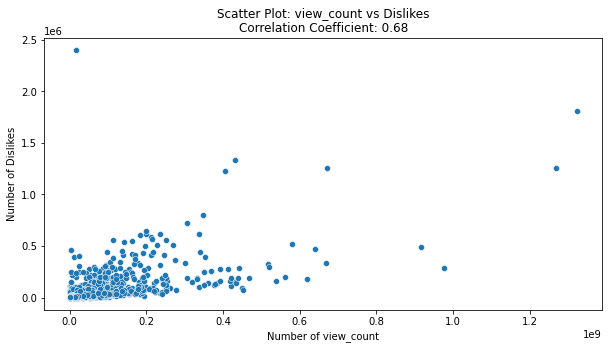

```python
# Calculating the correlation coefficient
correlation_coefficient = data['view_count'].corr(data['dislikes'])

# Creating a scatter plot
plt.figure(figsize=(10, 5))   #size of the scatter plot
sns.scatterplot(x='view_count', y='dislikes', data=data)
plt.title(f'Scatter Plot: view_count vs Dislikes\nCorrelation Coefficient: {correlation_coefficient:.2f}')
plt.xlabel('Number of view_count')
plt.ylabel('Number of Dislikes')
plt.show()
```

# QUESTION NO 14.

# Display all the information about the videos that were published in January, and mention the count of videos that were published in January.

```python
# Filtering data for videos published in January
videos_published_in_january = data[data['published_month'] == 'Jan']

# the videos published in January
print("Information about videos published in January:")
print(videos_published_in_january)

# the count of videos published in January
count_videos_in_january = len(videos_published_in_january)
print(f"\nCount of videos published in January: {count_videos_in_january}")
```

```
Information about videos published in January:
          video_id                                              title  \
27     -2Gwm7QfBnE                                    Q&A With Naisha
48     -4sfXSHSxzA           SURPRISING BRENT WITH HIS TIKTOK CRUSH!!
95     -AJD1Fc5rpQ  WE ARE HAVING A BABY! | finding out i'm pregna...
103    -AuJiwjsmWk              Do Ugly Foods Taste Worse? Taste Test
182    -JhqO2KWr5U                                   Schlatt gets fit
...            ...                                                ...
37300  zmzFL5bG-jc  DEVINE MON PERSONNAGE AVANT AKINATOR ! (c'est ...
37329  zpzjex7qwrA  Lampard Sacked Within Days Rorys Misery | Chel...
37345  zqyv-B6mnBM                 Lil Wayne - Ain't Got Time (Audio)
37383  zwfu1-24T7Q  PRADA Cup Day 1 | Full Race Replay | PRADA Cup...
37418  zziBybeSAtw  PELICANS at LAKERS | FULL GAME HIGHLIGHTS | Ja...

                     channel_id       channel_title        published_at  \
```

[output cut: 67 more lines]

# PROJECT COMPLETED :)